# Prediction

Ben Myall

17/05/2020

# Predicton

Using devices such as Jawbone Up, Nike FuelBand, and Fitbit it is now possible to collect a large amount of data about personal activity relatively inexpensively. These type of devices are part of the quantified self movement – a group of enthusiasts who take measurements about themselves regularly to improve their health, to find patterns in their behavior, or because they are tech geeks. One thing that people regularly do is quantify how much of a particular activity they do, but they rarely quantify how well they do it. In this project, your goal will be to use data from accelerometers on the belt, forearm, arm, and dumbell of 6 participants. They were asked to perform barbell lifts correctly and incorrectly in 5 different ways. More information is available from the website here: http://groupware.les.inf.puc-rio.br/har (see the section on the Weight Lifting Exercise Dataset).

What We wish to predict in this project is the classe variable, and we can do this by testing a few different prediction models and trying to find the one with the smallest error, then once that is done we can apply the best model to the test data to see what values we can expect. First we must load packages that we suspect we may use, as well as clean the datasets in such a way that N/A values are accounted for and dealt with

```r
library(ggplot2)
library(caret)
library(pgmm)
library(rpart)
library(gbm)
library(e1071)
library(glmnet)
library(elasticnet)
library(randomForest)
library(dplyr)
library(klaR)
library(rattle)
train <- read.csv(url("https://d396qusza40orc.cloudfront.net/predmachlearn/pml-training.csv"),
                  header = TRUE,
                  na.strings = c("NA", "", "#DIV/0!"))
test <- read.csv(url("https://d396qusza40orc.cloudfront.net/predmachlearn/pml-testing.csv"),
                 header = TRUE,
                 na.strings = c("NA", "", "#DIV/0!"))

traincl <- train %>%
  dplyr::select(-(1:7)) %>%
  select_if(colSums(is.na(.)) == 0) %>%

  mutate(classe = as.factor(classe))
testcl <- test %>%
  dplyr::select(-(1:7)) %>%
  select_if(colSums(is.na(.)) == 0)
```

## Model Selection

Once we have this we can look at some models to see which one has a low enougth error to make our prediction, we will first look at a linear discriminat analysis, applying a 5 fold cross validation.

```r
modlda <- train(classe ~ .,
                data = traincl,
                method = "lda",
                trControl = trainControl(method = "cv", number = 5))
cmlda <- confusionMatrix(predict(modlda, traincl), traincl$classe)
cmlda$table
```

```
##           Reference
## Prediction    A    B    C    D    E
##          A 4568  586  341  191  133
##          B  121 2429  333  130  611
##          C  444  455 2254  379  323
##          D  429  148  411 2383  344
##          E   18  179   83  133 2196
```

```r
cmlda$overall[1]
```

```
##  Accuracy
## 0.7048211
```

as we can see the accurate is around 0.705, so there is a good chance there is a better model out there. Next we will look at the desicion tree model.

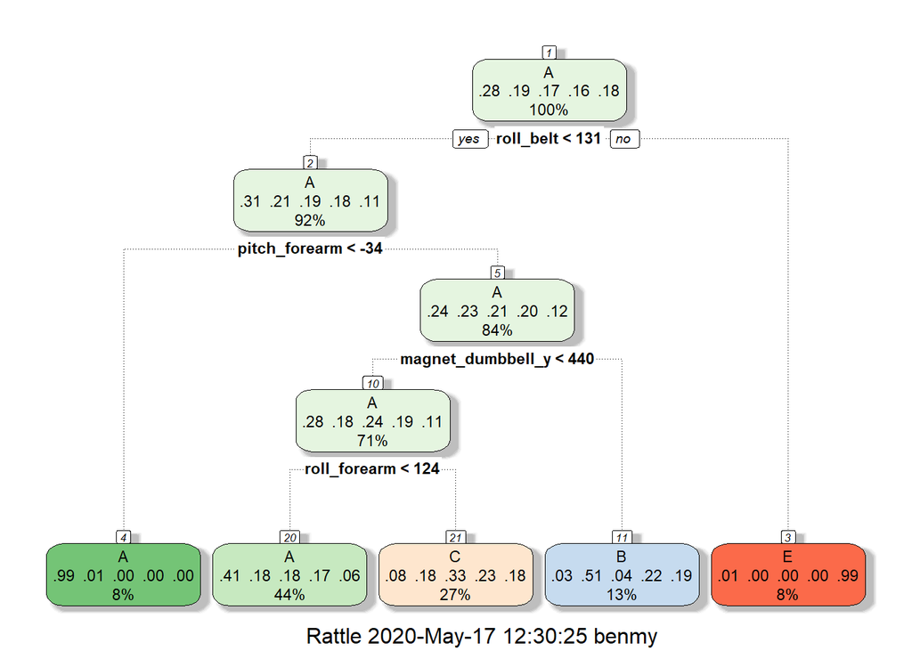

```r
decisionTreeMod1 <- train(classe ~ ., method="rpart", data=traincl,trControl = trainControl(method = "cv", number = 5))
fancyRpartPlot(decisionTreeMod1$finalModel)
```

```r
predictTreeMod1 <- predict(decisionTreeMod1, traincl)
tree <- confusionMatrix(predictTreeMod1, traincl$classe)
tree$table
```

```
##           Reference
## Prediction    A    B    C    D    E
##          A 5080 1581 1587 1449  524
##          B   81 1286  108  568  486
##          C  405  930 1727 1199  966
##          D    0    0    0    0    0
##          E   14    0    0    0 1631
```

```r
tree$overall[1]
```

```
##  Accuracy
## 0.4955662
```

The accuracy for this is 0.496, so this model can still be beaten, so next we want to look at a random forest

```r
randomForestMod1 <- train(classe ~ ., data=traincl, method="rf",trControl = trainControl(method = "cv", number = 5))
randomForestMod1$finalModel
```

```
##
## Call:
##  randomForest(x = x, y = y, mtry = param$mtry)
##                Type of random forest: classification
##                      Number of trees: 500
## No. of variables tried at each split: 27
##
##         OOB estimate of  error rate: 0.43%
## Confusion matrix:
##      A    B    C    D    E class.error
## A 5573    5    1    0    1 0.001254480
## B   19 3775    3    0    0 0.005794048
## C    0   10 3403    9    0 0.005552309
## D    0    0   22 3190    4 0.008084577
## E    0    1    2    7 3597 0.002772387
```

```r
predictForestMod1<- predict(randomForestMod1, traincl)
forest<- confusionMatrix(predictForestMod1, traincl$classe)
forest$table
```

```
##           Reference
## Prediction    A    B    C    D    E
##          A 5580    0    0    0    0
##          B    0 3797    0    0    0
##          C    0    0 3422    0    0
##          D    0    0    0 3216    0
##          E    0    0    0    0 3607
```

We can then see fom this that the random forest has a very high accuracy, so this is the prediction model we will use in our prediction

## Predicting the test set

The final part of this project is to predict the classe values in our test set, which we do with the following

```r
quizTest<- predict(randomForestMod1, testcl)
quizTest
```

```
##  [1] B A B A A E D B A A B C B A E E A B B B
## Levels: A B C D E
```